DP**Algoritmos visuales**Capítulo 11

Aprender haciendo · Capítulo 11

# Programación *dinámica*

Convierte un problema grande en una cuadrícula de pequeñas decisiones. Explora cada celda, descubre la recurrencia y comprueba por qué la solución óptima emerge paso a paso.

11

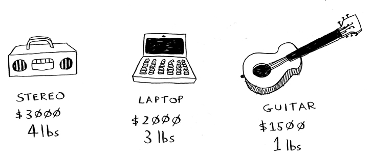

**Problema de la mochila**Figura del capítulo

◫

### 1. Define el estado

Cada celda representa la mejor respuesta para una versión más pequeña del problema.

1

↙

### 2. Reutiliza soluciones

En vez de recalcular, consulta resultados de subproblemas ya resueltos.

2

↑

### 3. Construye lo óptimo

Compara alternativas locales con una recurrencia que preserva la mejor decisión.

3

### Tu ruta interactiva

Laboratorio 01

## La mochila, celda a celda

La decisión en cada celda es binaria: excluir el objeto actual o incluirlo y aprovechar el mejor valor del espacio restante.

Datos del libro Capacidad: 4 lb

16

Objetos disponibles

Consejo: observa cómo una celda puede “mirar” arriba y hacia una capacidad menor.

**Tabla DP**

0 de 12 celdas

Preparada

Pulsa **Siguiente celda** para iniciar. La fila 0 vale siempre $0: sin objetos no hay valor.

Completa la cuadrícula para descubrir el óptimo.**—**

### La recurrencia

si pesoᵢ > c:  
DP[i,c] = DP[i−1,c]  
si cabe:  
DP[i,c] = max(  
DP[i−1,c],  
valorᵢ + DP[i−1,c−pesoᵢ]  
)

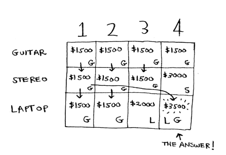

Figura original: la celda final combina portátil + guitarra = $3.500.

Laboratorio 02

## ¿Qué visitar en Londres?

El mismo patrón cambia de historia: la capacidad ahora es tiempo, los objetos son lugares y el valor es cuánto deseas visitarlos.

### Diseña tu itinerario

Unidad: ½ día

Tiempo disponible: 2 días

½4 días

Activa o desactiva lugares. El plan se recalcula de inmediato.

Valor total del itinerario**24 pts**

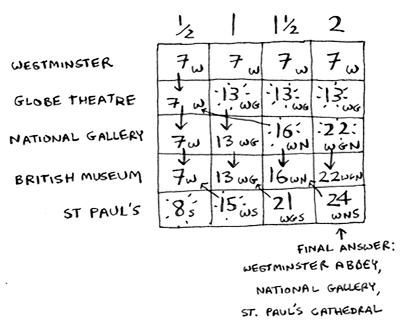

Figura original del capítulo: Westminster, National Gallery y St. Paul’s forman el mejor plan para 2 días.

### La tabla detrás del plan

Cada columna añade medio día de capacidad.

3 paradas

⚠

**Límite importante**

La versión simple supone subproblemas independientes. Si visitar París abarata otras visitas en París, aparece una dependencia que este modelo no representa.

½

**Granularidad**

Si existe una actividad de medio día, las columnas deben avanzar de medio en medio. El tamaño de la unidad cambia la tabla.

Laboratorio 03

## La cuadrícula de las palabras

Compara tres preguntas parecidas pero distintas. Cambiar qué significa una celda cambia la recurrencia y también dónde aparece la respuesta.

Compara las primeras letras. Pulsa **Revelar celda** y observa la dirección de la dependencia.

Substring más largo**—**

### Substring común más largo

Busca caracteres contiguos. Si las letras coinciden, suma 1 a la diagonal; si no, reinicia en cero.

igual → diagonal + 1  
distinto → 0  
respuesta → máximo global

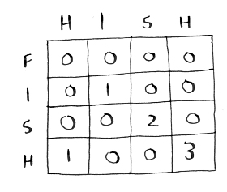

Figura original: HISH y FISH comparten el substring “ISH”, de longitud 3.

### ¿Qué cambia entre los tres?

| Método | Pregunta | Cuando no coinciden | Respuesta |
| --- | --- | --- | --- |
| **Substring** | ¿Cuál bloque contiguo comparten? | La celda vuelve a 0 | Máximo de toda la tabla |
| **Subsecuencia** | ¿Cuál secuencia ordenada comparten? | Máximo entre arriba e izquierda | Última celda |
| **Levenshtein** | ¿Cuántas ediciones mínimas las separan? | Mínimo + costo de editar | Última celda |

Evaluación formativa

## ¿Ya piensas en subproblemas?

Ocho preguntas cortas. Cada respuesta explica por qué, para convertir el error en una pista útil.

Pregunta 1 de 8

Selecciona una respuesta.

### Tu progreso

**0**correctas

La tabla también se aprende celda a celda.

Mapa de cierre

## Reconocer un problema DP

No existe una receta automática para inventar la recurrencia, pero estas preguntas organizan el razonamiento.

### Señales favorables

- Debes maximizar, minimizar o contar algo.
- Existe una restricción clara: peso, tiempo, presupuesto o longitud.
- El problema puede dividirse en subproblemas discretos.
- Los mismos subproblemas aparecen repetidamente.
- La respuesta grande puede construirse desde respuestas pequeñas.

### Diseña la cuadrícula

1. **Define la celda.** Escribe en una frase qué significa DP[i,j].
2. **Elige los ejes.** ¿Qué dos dimensiones hacen más pequeños los subproblemas?
3. **Fija los casos base.** ¿Qué ocurre con cero objetos, cero capacidad o cadena vacía?
4. **Encuentra la transición.** ¿De qué celdas anteriores depende la actual?
5. **Ubica la respuesta.** ¿Está al final o es el máximo global?

🎒

### Mochila 0/1

**Estado:** mejor valor con los primeros i objetos y capacidad c.

01

🔤

### Substring

**Estado:** longitud del bloque común que termina exactamente en i,j.

02

🧬

### Subsecuencia

**Estado:** mejor longitud usando los primeros i y j caracteres.

03

◎

**Idea esencial**

Programación dinámica no significa llenar tablas por llenar tablas. Significa guardar el resultado exacto de un subproblema para construir otros sin repetir trabajo.